# timeSeriesModel

--------------------------------------------------------------------- --------------------Time Series Modeling v.1.0.0--------------------- Created by: David Hodge Created on: 2020-5-9 Description: This script is used for performing a Time Series Analysis on a given dataset Version: 1.0.0 - Initial script created ---------------------------------------------------------------------

```python
# Import libraries
import pandas as pd
import matplotlib.pyplot as plt
#
from math import sqrt
from pmdarima.arima import auto_arima
from scipy.signal import welch
from sklearn.metrics import mean_absolute_error, mean_squared_error
from sklearn.metrics import mean_absolute_percentage_error
from statsmodels.graphics.tsaplots import plot_acf
from statsmodels.tsa.seasonal import STL
from statsmodels.tsa.stattools import adfuller
```

Method: BuildARIMA Inputs: df = A Pandas dataframe object Processing: The BuildARIMA method fits the ARIMA model to the dataset using the determined parameters Output: Returns the ARIMA model

```python
def BuildARIMA(df):
#
    # Create the ARIMA model using the optimized parameters
    model = auto_arima(df.Revenue,
                       seasonal = True,
                       d = None,
                       m = 1)
    return model
```

```python
def CleanDF(df, idx, output, title):
#
    # Create a Pandas dataframe object from the .csv dataset
    df = pd.read_csv(df)
#
    # Create a copy of the dataframe to be used for cleaning
    df_clean = df.copy()
#
    # Set the index of the dataframe, and convert it to datetime
    df_clean[str(idx)] = pd.to_datetime(df_clean[str(idx)])
    df_clean = df_clean.set_index(idx)
    df_clean.index = pd.DatetimeIndex(df_clean.index.values,
                                      freq=df_clean.index.inferred_freq)
#
    # Save the dataframe to the output directory
    df_clean.to_csv(output +
                    title +
                    '.csv')
    # Plot the dataframe
    plt.figure(figsize=(10,8))
    plt.plot(df_clean)
    plt.xlabel('Date')
    plt.ylabel('Revenue (in Millions)')
    plt.savefig(output +
                'Time Series Graph.png')
    plt.show()
#
    return df_clean
```

Method: ExportSummary Inputs: obj = The object to write to the text file output = Folder directory as string object title = A string object for the title of the file Processing: The ExportSummary writes the summary of an object to a text file. Output: None

```python
def ExportSummary(obj, output, title):
#
    # Writes the summary to a text file
    file = open(output +
                title +
                '.txt',
                'w')
    file.write(str(obj.summary()))
    print(obj.summary())
```

```python
def ForecastModel(df, model, days, output):
#
    # Forecasting the model into the future
    forc, conint = model.predict(n_periods = days,
                                 return_conf_int = True)
    forc_idx = pd.date_range(df.index[df.shape[0]-1],
                             periods = days,
                             freq = 'D')
    forc_series = pd.Series(forc,
                            index = forc_idx)
    lwr_series = pd.Series(conint[:, 0],
                           index = forc_idx)
    upr_series = pd.Series(conint[:, 1],
                           index = forc_idx)
#
    # Plot the predictions
    plt.figure(figsize=(10,8))
    plt.plot(df)
    plt.plot(forc_series)
    plt.xlabel('Date')
    plt.ylabel('Revenue (in Millions)')
    plt.fill_between(lwr_series.index,
                     lwr_series,
                     upr_series,
                     color = 'k',
                     alpha = 0.25)
    plt.legend(('Actual Revenue',
                'Forecasted Revenue',
                '95% Confidence Intervel'),
               loc='upper left')
    plt.savefig(output +
                '{} Day Prediction.png'.format(days))
    plt.show()
#
    return forc
```

Method: PlotCorrelation Inputs: df = A pandas dataframe object output = Folder directory as string object Processing: The PlotCorrelation plots the autocorrelation of the dataframe Output: None

```python
def PlotCorrelation(df, output, title):
#
    # Plot the autocorrelation of the dataframe
    plt.rcParams.update({'figure.figsize':(10,8),
                         'figure.dpi':120})
    plot_acf(df.Revenue)
    plt.title(title)
    plt.savefig(output +
                '{}.png'.format(title))
    plt.show()
```

```python
def PlotDecomp(df, output, title):
#
    # Plot the decomposition of the dataframe
    plt.rcParams.update({'figure.figsize':(10,8),
                         'figure.dpi':120})
    dec = STL(df,
              robust = True).fit()
#
    # Plot the decomposition
    dec.plot()
    plt.savefig(output +
                '{}.png'.format(title))
    plt.show()
#
    return dec
```

```python
def PlotDensity(df, output, title):
#
    # Plot the decomposition of the dataframe
    plt.rcParams.update({'figure.figsize':(10,8),
                         'figure.dpi':120})
    f, den = welch(df.Revenue)
#
    # Plot the decomposition
    plt.semilogy(f, den)
    plt.savefig(output +
                '{}.png'.format(title))
    plt.show()
```

Method: PredictAccuracy Inputs: pred = A predicted model forecast object testDF = A Pandas dataframe object Processing: The PredictAccuracy calculates the accuracy of the test model Output: None

```python
def PredictAccuracy(pred, testDF, model, output):
#
    # Determine model accuracy metrics
    print('Determining model accuracy...')
    print('')
    print('Initial Model Metrics:')
    print('Mean Absolute Error: {:.3f}'.format(mean_absolute_error(testDF,
                                                                   pred)))
    print('Mean Absolute Percent Error: {:.3f}'.format(
                                mean_absolute_percentage_error(testDF,
                                                               pred)*100))
    print('Mean Squared Error: {:.3f}'.format(mean_squared_error(testDF,
                                                                 pred)))
    print('Root Mean Squared Error: {:.3f}'.format(sqrt(mean_squared_error(
                                                                       testDF,
                                                                       pred))))
    print('')
#
    # Plot the models residuals
    residu = pd.DataFrame(model.resid())
    residu.plot()
    plt.savefig(output +
                'Test Model Residuals.png')
    plt.show()
#
    # Determine residual distribution
    residu.plot(kind='kde')
    plt.savefig(output +
                'Test Model Distribution.png')
    plt.show()
```

Method: PredictModel Inputs: model = A fitted ARIMA model object df = A pandas dataframe object start = Int object representing length of dataset test = Int object representing length of test dataset output = Folder directory as string object Processing: The PredictModel plots the predictions of the test dataset against the training dataset Output: None

```python
def PredictModel(model, trainDF, testDF, days, output):
#
    # Run prediction against the test dataset
    pred = pd.DataFrame(model.predict(n_periods = days),
                        index=testDF.index)
    pred.columns = ['Predicted_Revenue']
#
    # Plot the predictions
    plt.figure(figsize=(10,8))
    plt.plot(trainDF,
             label='Training')
    plt.plot(testDF,
             label='Testing')
    plt.plot(pred,
             label='Predicted')
    plt.legend(loc='upper left')
    plt.savefig(output +
                '{} {}.png'.format(days,
                                   'Day Prediction'))
    plt.show()
#
    return pred
```

Method: SplitDataset Inputs: df = df = A Pandas dataframe object output = A string object used to specify the directory to save the dataframe Processing: The SplitDataset method splits the input dataframe object into seperate training and testing dataframes Output: trainDF = A pandas dataframe object testDF = A pandas dataframe object

```python
def SplitDataset(df, split, output):
#
    # Split the dataframe into training and testing dataframes
    trainDf = df.iloc[:split,:]
    testDf = df.iloc[split:,:]
    trainDf.to_csv(output +
                   'Revenue_train.csv')
    testDf.to_csv(output +
                   'Revenue_test.csv')
    return trainDf, testDf
```

Method: TestStationary Inputs: df = A pandas dataframe object Processing: The TestStationary tests the stationary of the dataframe Output: None

```python
def TestStationary(df):
#
    # Test if the dataset is stationary
    stat = adfuller(df.Revenue.dropna())
#
    print('')
    print('Dataset Metrics:')
    print('ADF Statistic: %.3f' % stat[0])
    print('p-value: %.3f' % stat[1])
    print('')
```

```python
# Initialize the variables to use in the program
directory = ('I:\\david\\Documents\\School\\WGU\\Courses\\' +
             'D213_Advanced_Data_Analytics\\' +
             'NLM2 Task 1 - Time Series Modeling\\')
outDir = (directory +
          'Output\\')
dataset = (directory +
          'teleco_time_series.csv')
index = 'Day'
```

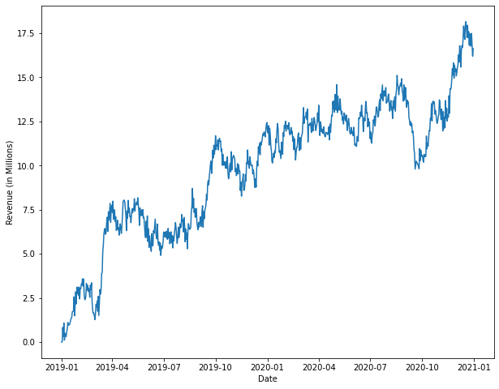

```python
# Clean the dataframe and set the index
telcoCln = CleanDF(dataset,
                    index,
                    outDir,
                    'Telco_Clean')
```

```python
# Determine if the dataset is stationary
TestStationary(telcoCln)
```

```
Dataset Metrics:
ADF Statistic: -1.925
p-value: 0.321
```

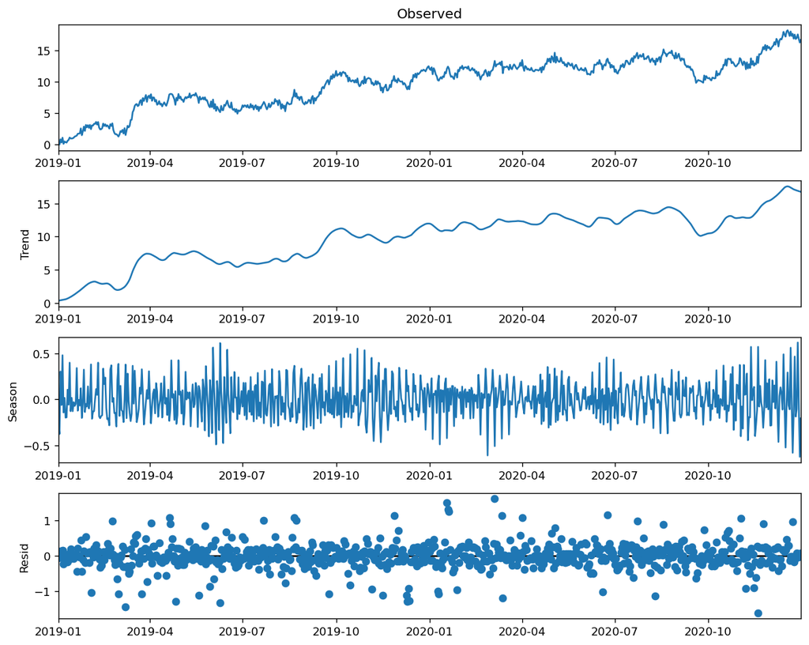

```python
# Plot the decomposition of the dataframe
dec = PlotDecomp(telcoCln,
                 outDir,
                 'Decomposition of Dataset')
```

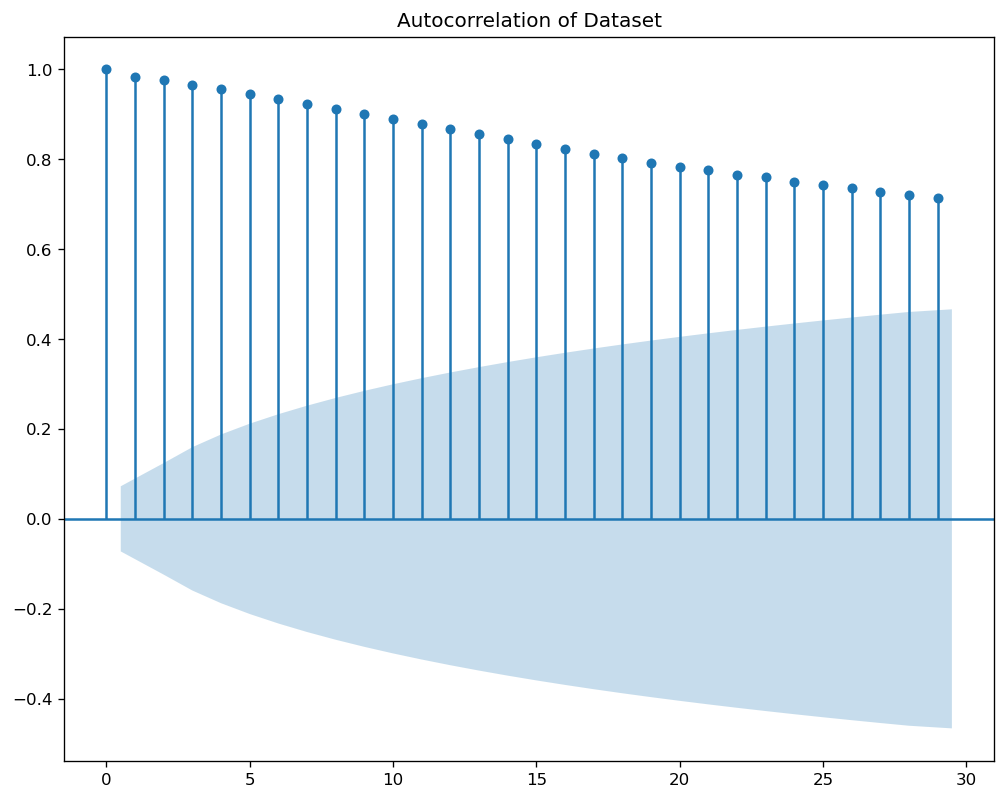

```python
# Plot the autocorrelation of the dataframe to test for
# seasonality
PlotCorrelation(telcoCln,
                outDir,
                'Autocorrelation of Dataset')
```

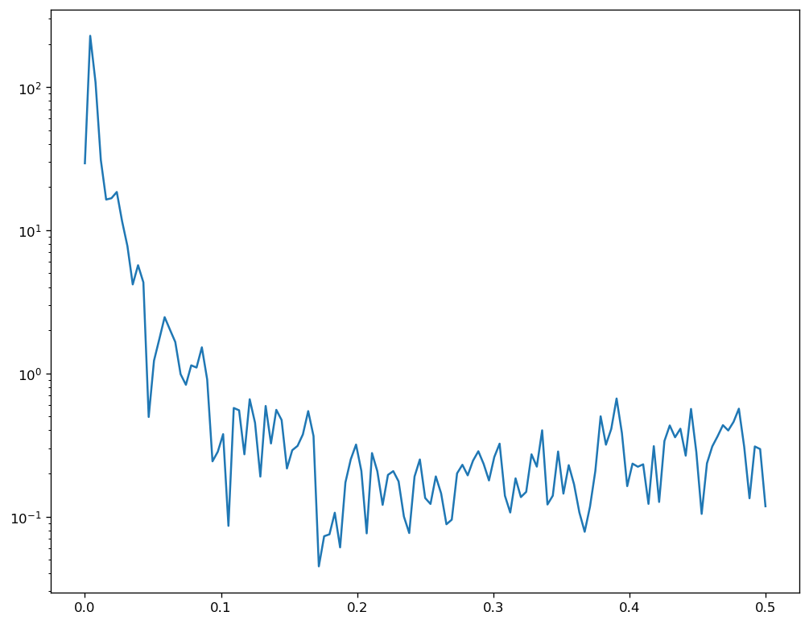

```python
# Plot the spectral density of the dataset
PlotDensity(telcoCln,
            outDir,
            'Spectral Density')
```

```python
# Split the dataset into training and testing datasets
trainDF, testDF = SplitDataset(telcoCln,
                               540,
                               outDir)
#
# Fit the ARIMA model to the training dataset
model = BuildARIMA(trainDF)
#
# Write the model summary to a text file
ExportSummary(model,
              outDir,
              'Training_Model_Summary')
```

```
                               SARIMAX Results
==============================================================================
Dep. Variable:                      y   No. Observations:                  540
Model:               SARIMAX(1, 1, 0)   Log Likelihood                -355.963
Date:                Sat, 22 May 2021   AIC                            717.925
Time:                        13:23:25   BIC                            730.794
Sample:                             0   HQIC                           722.959
                                - 540
Covariance Type:                  opg
==============================================================================
                 coef    std err          z      P>|z|      [0.025      0.975]
------------------------------------------------------------------------------
intercept      0.0359      0.020      1.769      0.077      -0.004       0.076
ar.L1         -0.4698      0.037    -12.586      0.000      -0.543      -0.397
sigma2         0.2193      0.014     15.621      0.000       0.192       0.247
===================================================================================
Ljung-Box (L1) (Q):                   0.00   Jarque-Bera (JB):                 1.14
Prob(Q):                              1.00   Prob(JB):                         0.57
Heteroskedasticity (H):               0.97   Skew:                            -0.07
Prob(H) (two-sided):                  0.86   Kurtosis:                         2.82
===================================================================================

Warnings:
[1] Covariance matrix calculated using the outer product of gradients (complex-step).
```

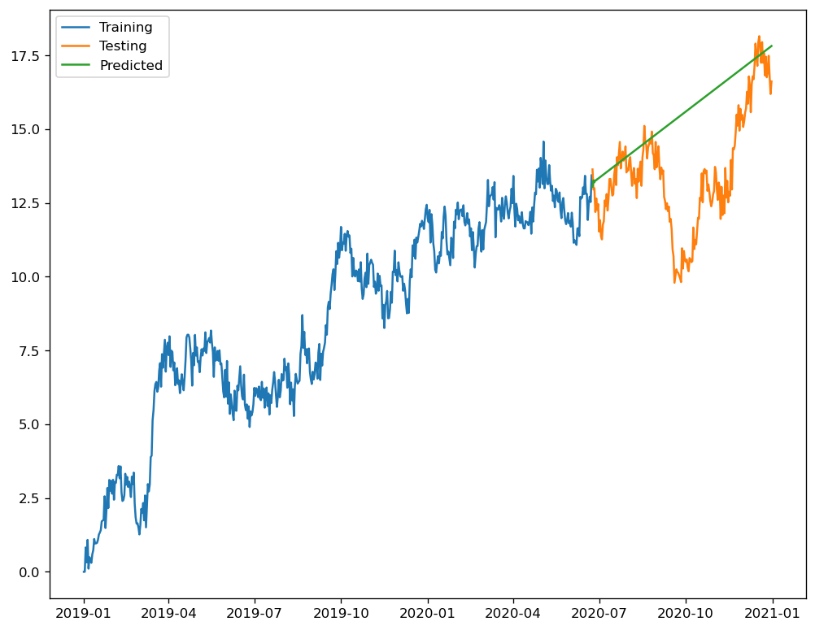

```python
# Verify the model against the testing dataset
pred = PredictModel(model,
                    trainDF,
                    testDF,
                    len(testDF),
                    outDir)
```

```
Determining model accuracy...

Initial Model Metrics:
Mean Absolute Error: 2.037
Mean Absolute Percent Error: 16.832
Mean Squared Error: 7.045
Root Mean Squared Error: 2.654
```

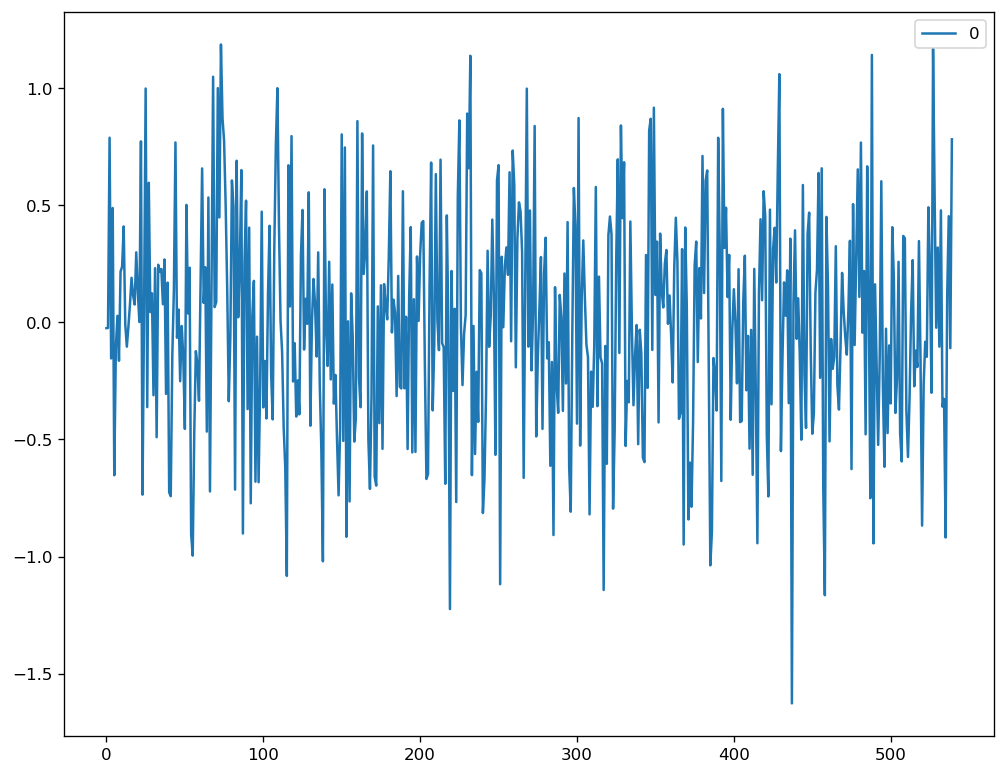

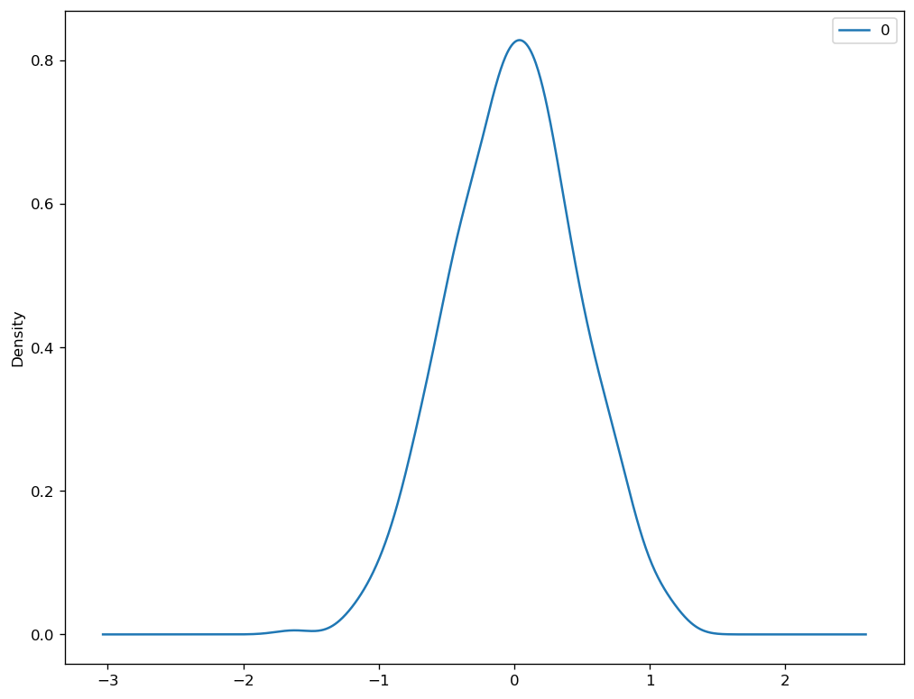

```python
# Calculate the ARIMA model accuracy
PredictAccuracy(pred,
                testDF,
                model,
                outDir)
```

```python
# Fit the ARIMA model to the full dataset
model = BuildARIMA(telcoCln)
#
# Write the model summary to a text file
ExportSummary(model,
              outDir,
              'Telco_Model_Summary')
```

```
                               SARIMAX Results
==============================================================================
Dep. Variable:                      y   No. Observations:                  731
Model:               SARIMAX(1, 1, 0)   Log Likelihood                -488.561
Date:                Sat, 22 May 2021   AIC                            983.122
Time:                        13:23:28   BIC                            996.901
Sample:                             0   HQIC                           988.438
                                - 731
Covariance Type:                  opg
==============================================================================
                 coef    std err          z      P>|z|      [0.025      0.975]
------------------------------------------------------------------------------
intercept      0.0332      0.018      1.895      0.058      -0.001       0.068
ar.L1         -0.4692      0.033    -14.296      0.000      -0.534      -0.405
sigma2         0.2232      0.013     17.801      0.000       0.199       0.248
===================================================================================
Ljung-Box (L1) (Q):                   0.00   Jarque-Bera (JB):                 2.05
Prob(Q):                              0.96   Prob(JB):                         0.36
Heteroskedasticity (H):               1.02   Skew:                            -0.02
Prob(H) (two-sided):                  0.85   Kurtosis:                         2.74
===================================================================================

Warnings:
[1] Covariance matrix calculated using the outer product of gradients (complex-step).
```

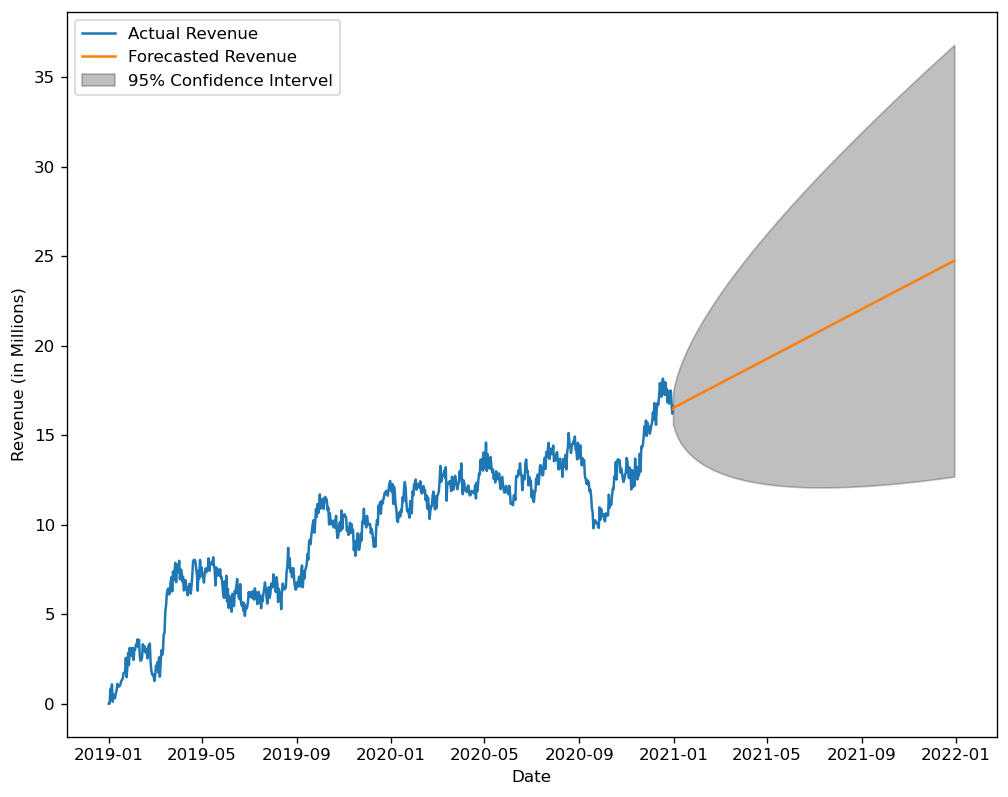

```python
# Forecast the dataset using the ARIMA model
forc = ForecastModel(telcoCln,
                     model,
                     365,
                     outDir)
```